# Interacciones en regresión

PSI4035 Taller 06

dacarras

# Taller 6: interaccion entre variables

## Cargar datos

```r
#----------------------------------------------------------
# cargar datos
#----------------------------------------------------------

#--------------------------------------
# cargar dplyr
#--------------------------------------

library(dplyr)
#--------------------------------------
# datos Vik (2014, p83)
#--------------------------------------

table_9_2 <- read.table(text = "
person      y    x1   x2
      1     2     8    1
      2     3     9    2
      3     3     9    2
      4     4    10    3
      5     7     6    8
      6     5     7    9
      7     5     4    9
      8     7     5   10
      9     8     3    5
     10     9     1    6
     11     9     2    7
     12    10     2    7
", header = TRUE, stringsAsFactors = FALSE)

#--------------------------------------
# funcion para crear medias por grupos
#--------------------------------------

c_mean <- function(x,j){
ave(x,j,FUN=function(x) mean(x, na.rm=T))
}


#--------------------------------------
# datos Vik (2014, p121)
#--------------------------------------

table_10_2 <- table_9_2 %>%
              mutate(group = 1) %>%
              mutate(x1_g = c_mean(x1, group)) %>%
              mutate(x2_g = c_mean(x2, group)) %>%
              mutate(x1_m = x1 - x1_g) %>%
              mutate(x2_m = x2 - x2_g) %>%
              mutate(x3   = x1_m * x2_m) %>%
              mutate(int  = x1_m * x2_m) %>%
              dplyr::glimpse()
```

```
## Rows: 12
## Columns: 11
## $ person <int> 1, 2, 3, 4, 5, 6, 7, 8, 9, 10, 11, 12
## $ y      <int> 2, 3, 3, 4, 7, 5, 5, 7, 8, 9, 9, 10
## $ x1     <int> 8, 9, 9, 10, 6, 7, 4, 5, 3, 1, 2, 2
## $ x2     <int> 1, 2, 2, 3, 8, 9, 9, 10, 5, 6, 7, 7
## $ group  <dbl> 1, 1, 1, 1, 1, 1, 1, 1, 1, 1, 1, 1
## $ x1_g   <dbl> 5.5, 5.5, 5.5, 5.5, 5.5, 5.5, 5.5, 5.5, 5.5, 5.5, 5.5, 5.5
## $ x2_g   <dbl> 5.75, 5.75, 5.75, 5.75, 5.75, 5.75, 5.75, 5.75, 5.75, 5.75, 5.7…
## $ x1_m   <dbl> 2.5, 3.5, 3.5, 4.5, 0.5, 1.5, -1.5, -0.5, -2.5, -4.5, -3.5, -3.5
## $ x2_m   <dbl> -4.75, -3.75, -3.75, -2.75, 2.25, 3.25, 3.25, 4.25, -0.75, 0.25…
## $ x3     <dbl> -11.875, -13.125, -13.125, -12.375, 1.125, 4.875, -4.875, -2.12…
## $ int    <dbl> -11.875, -13.125, -13.125, -12.375, 1.125, 4.875, -4.875, -2.12…
```

```r
#--------------------------------------
# mostrar datos
#--------------------------------------

knitr::kable(table_10_2, digits = 3)
```

| person | y | x1 | x2 | group | x1_g | x2_g | x1_m | x2_m | x3 | int |
| --- | --- | --- | --- | --- | --- | --- | --- | --- | --- | --- |
| 1 | 2 | 8 | 1 | 1 | 5.5 | 5.75 | 2.5 | -4.75 | -11.875 | -11.875 |
| 2 | 3 | 9 | 2 | 1 | 5.5 | 5.75 | 3.5 | -3.75 | -13.125 | -13.125 |
| 3 | 3 | 9 | 2 | 1 | 5.5 | 5.75 | 3.5 | -3.75 | -13.125 | -13.125 |
| 4 | 4 | 10 | 3 | 1 | 5.5 | 5.75 | 4.5 | -2.75 | -12.375 | -12.375 |
| 5 | 7 | 6 | 8 | 1 | 5.5 | 5.75 | 0.5 | 2.25 | 1.125 | 1.125 |
| 6 | 5 | 7 | 9 | 1 | 5.5 | 5.75 | 1.5 | 3.25 | 4.875 | 4.875 |
| 7 | 5 | 4 | 9 | 1 | 5.5 | 5.75 | -1.5 | 3.25 | -4.875 | -4.875 |
| 8 | 7 | 5 | 10 | 1 | 5.5 | 5.75 | -0.5 | 4.25 | -2.125 | -2.125 |
| 9 | 8 | 3 | 5 | 1 | 5.5 | 5.75 | -2.5 | -0.75 | 1.875 | 1.875 |
| 10 | 9 | 1 | 6 | 1 | 5.5 | 5.75 | -4.5 | 0.25 | -1.125 | -1.125 |
| 11 | 9 | 2 | 7 | 1 | 5.5 | 5.75 | -3.5 | 1.25 | -4.375 | -4.375 |
| 12 | 10 | 2 | 7 | 1 | 5.5 | 5.75 | -3.5 | 1.25 | -4.375 | -4.375 |

## Ajustar modelos

```r
#----------------------------------------------------------
# cargar datos
#----------------------------------------------------------

data_model <- table_10_2

#--------------------------------------
# formulas
#--------------------------------------

f01 <- as.formula(y ~ + 1)
f02 <- as.formula(y ~ + 1 + x1_m)
f03 <- as.formula(y ~ + 1 + x2_m)
f04 <- as.formula(y ~ + 1 + x1_m + x2_m)
f05 <- as.formula(y ~ + 1 + x1_m + x2_m + x3)

#--------------------------------------
# ajustar modelos
#--------------------------------------

m01 <- lm(f01, data = data_model)
m02 <- lm(f02, data = data_model)
m03 <- lm(f03, data = data_model)
m04 <- lm(f04, data = data_model)
m05 <- lm(f05, data = data_model)

#--------------------------------------
# comparar modelos de forma sintética
#--------------------------------------

texreg::screenreg(
    list(m01, m02, m03, m04, m05),
    star.symbol = "*",
    center = TRUE,
    doctype = FALSE,
    dcolumn = TRUE,
    booktabs = TRUE,
    single.row = FALSE
    )
```

```
##
## ==================================================================
##              Model 1    Model 2    Model 3    Model 4    Model 5
## ------------------------------------------------------------------
## (Intercept)   6.00 ***   6.00 ***   6.00 ***   6.00 ***   6.23 ***
##              (0.78)     (0.36)     (0.66)     (0.37)     (0.66)
## x1_m                    -0.78 ***             -0.71 ***  -0.69 **
##                         (0.12)                (0.15)     (0.16)
## x2_m                                0.52 *     0.12       0.06
##                                    (0.22)     (0.15)     (0.21)
## x3                                                        0.05
##                                                          (0.11)
## ------------------------------------------------------------------
## R^2           0.00       0.80       0.36       0.82       0.82
## Adj. R^2      0.00       0.79       0.29       0.78       0.76
## Num. obs.    12         12         12         12         12
## ==================================================================
## *** p < 0.001; ** p < 0.01; * p < 0.05
```

## Comparar modelos

```r
#----------------------------------------------------------
# comparar modelos
#----------------------------------------------------------

#--------------------------------------
# anova: model building
#--------------------------------------

anova(m04, m05)
```

```
## Analysis of Variance Table
##
## Model 1: y ~ +1 + x1_m + x2_m
## Model 2: y ~ +1 + x1_m + x2_m + x3
##   Res.Df    RSS Df Sum of Sq      F Pr(>F)
## 1      9 14.547
## 2      8 14.214  1   0.33343 0.1877 0.6763
```

# Ejemplo 1: interaccion entre variables dicotómicas

Para ilustrar una interacción, vamos a emplear datos de Abrevaya (2006). Estos son una serie de registros del peso al nacer de los hijos de diferentes madres. La motivación del estudio, es evaluar el efecto que posee el fumar en el peso de los nacidos. Este ejemplo se encuentra discutido con mayor profundidad en Rabe-Hesketh & Skrondal (2012), y consiste en un 10% de los datos originales (n = 3978 madres).

En el caso de la regresión múltiple, nos sigue interesando los valores esperados de y_i, condicionales a los valores de x_i y otras covariables.

Primero vamos a evaluar la interacción de dos variables dicotómicas.

## Abrir datos

```r
#----------------------------------------------------------
# abrir datos
#----------------------------------------------------------

# -----------------------------------------------
# abrir datos desde github
# -----------------------------------------------

data_smoke <- haven::read_dta(
url('https://github.com/dacarras/psi4035_examples/raw/master/data/smoking.dta')
)

# Nota: el formato original de los datos, esta en STATA.
#       empleamos haven::read_dta() para abrir datos en este formato.

# -----------------------------------------------
# inspeccionar datos
# -----------------------------------------------

data_smoke %>%
labelled::look_for() %>%
labelled::lookfor_to_long_format() %>%
tibble::as_tibble() %>%
knitr::kable()
```

| pos | variable | label | col_type | levels | value_labels |
| --- | --- | --- | --- | --- | --- |
| 1 | momid |  | dbl |  |  |
| 2 | idx |  | dbl |  |  |
| 3 | stateres |  | dbl+lbl |  | [1] AL |
| 3 | stateres |  | dbl+lbl |  | [2] AK |
| 3 | stateres |  | dbl+lbl |  | [3] AZ |
| 3 | stateres |  | dbl+lbl |  | [4] AR |
| 3 | stateres |  | dbl+lbl |  | [5] CA |
| 3 | stateres |  | dbl+lbl |  | [6] CO |
| 3 | stateres |  | dbl+lbl |  | [7] CT |
| 3 | stateres |  | dbl+lbl |  | [8] DE |
| 3 | stateres |  | dbl+lbl |  | [9] DC |
| 3 | stateres |  | dbl+lbl |  | [10] FL |
| 3 | stateres |  | dbl+lbl |  | [11] GA |
| 3 | stateres |  | dbl+lbl |  | [12] HI |
| 3 | stateres |  | dbl+lbl |  | [13] ID |
| 3 | stateres |  | dbl+lbl |  | [14] IL |
| 3 | stateres |  | dbl+lbl |  | [15] IN |
| 3 | stateres |  | dbl+lbl |  | [16] IA |
| 3 | stateres |  | dbl+lbl |  | [17] KS |
| 3 | stateres |  | dbl+lbl |  | [18] KY |
| 3 | stateres |  | dbl+lbl |  | [19] LA |
| 3 | stateres |  | dbl+lbl |  | [20] ME |
| 3 | stateres |  | dbl+lbl |  | [21] MD |
| 3 | stateres |  | dbl+lbl |  | [22] MA |
| 3 | stateres |  | dbl+lbl |  | [23] MI |
| 3 | stateres |  | dbl+lbl |  | [24] MN |
| 3 | stateres |  | dbl+lbl |  | [25] MS |
| 3 | stateres |  | dbl+lbl |  | [26] MO |
| 3 | stateres |  | dbl+lbl |  | [27] MT |
| 3 | stateres |  | dbl+lbl |  | [28] NE |

[output cut: 97 more lines]

## Preparar datos

Seleccionamos los datos del primer hijo, de modo que tengamos datos independientes. En caso contrario, tendríamos datos de más de un nacido de una misma madres, y estaríamos violando el supuesto de independencia de las observaciones.

Vamos a emplear solo tres medidas: el peso al nacer, si la madre fuma (0 = no fuma; 1 = si fuma), y si ha faltado a los controles pre natales (1 = sin visita, 0 = con visitas).

El peso de los recién nacidos esta en gramos, así que lo convertiremos a kilos, de modo que sea más fácil de interpretar (i.e. leer los estimados en Kg.).

Luego ajustamos los modelos de regresión en pasos. Primero solo la covariable de interés (smoke). Luego, el posible moderador (novisit), y finalmente un modelo con ambos predictores y su interacción.

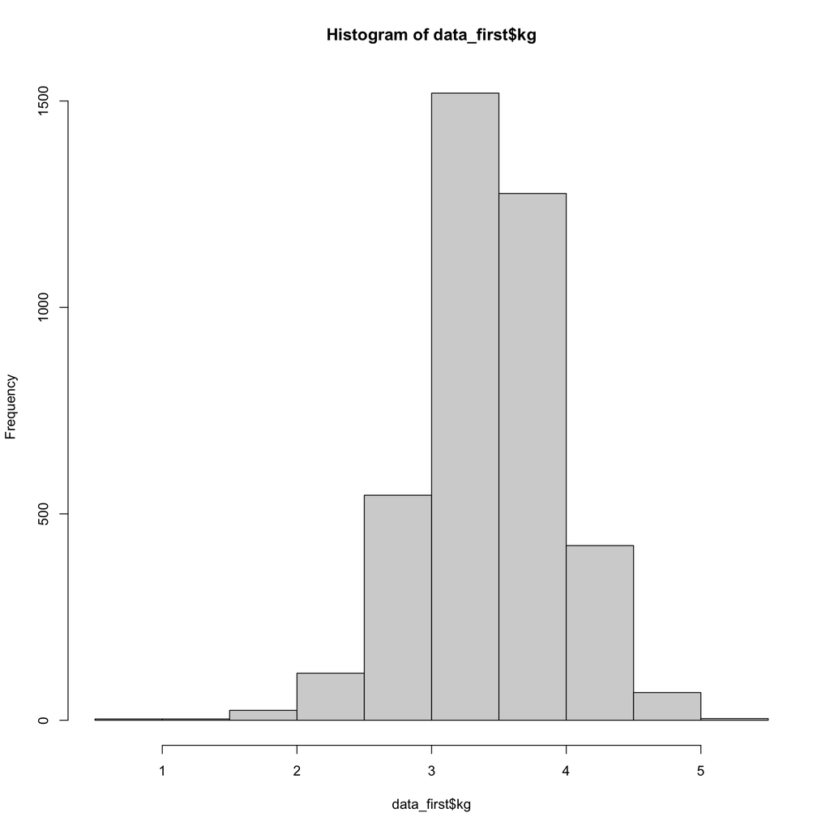

```r
#----------------------------------------------------------
# preparar datos
#----------------------------------------------------------

# -----------------------------------------------
# variables de interes
# -----------------------------------------------

# momid   = indicador único de la madre
# idx     = orden de los nacidos para cada madre
# birwt   = peso al nacer en gramos
# smoke   = madre es fumadora (sí = 1; no = 0)
# novisit = no asiste al control prenatal (no = 1; sí = 0)


# -----------------------------------------------
# funcion para remover meta data
# -----------------------------------------------

remove_labels <- function (x) {
    data <- dplyr::mutate(x, across(everything(), as.vector))
    return(data)
}

# -----------------------------------------------
# preparar datos
# -----------------------------------------------

data_first <- data_smoke %>%
              # seleccionamos datos solo del primer hijo
              dplyr::filter(idx == 1) %>%
              # transformamos el peso a kilogramos
              mutate(kg = birwt/1000) %>%
              # seleccionamos solo los datos que vamos a emplear
              dplyr::select(momid, idx, kg, smoke, novisit) %>%
              remove_labels() %>%
              as.data.frame()


# -----------------------------------------------
# histograma
# -----------------------------------------------

hist(data_first$kg)
```

```r
# -----------------------------------------------
# mostrar datos de 20 casos
# -----------------------------------------------

data_first %>%
dplyr::sample_n(20) %>%
tibble::as_tibble() %>%
knitr::kable()
```

| momid | idx | kg | smoke | novisit |
| --- | --- | --- | --- | --- |
| 58877 | 1 | 3.345 | 0 | 0 |
| 5311 | 1 | 3.969 | 0 | 0 |
| 29432 | 1 | 4.196 | 0 | 0 |
| 6723 | 1 | 3.430 | 0 | 0 |
| 3495 | 1 | 4.394 | 0 | 0 |
| 58937 | 1 | 3.246 | 0 | 0 |
| 22314 | 1 | 2.809 | 1 | 0 |
| 75733 | 1 | 3.544 | 0 | 0 |
| 33316 | 1 | 3.690 | 0 | 0 |
| 83025 | 1 | 2.665 | 0 | 0 |
| 43334 | 1 | 3.515 | 0 | 0 |
| 58531 | 1 | 3.175 | 0 | 0 |
| 92052 | 1 | 3.997 | 0 | 0 |
| 37788 | 1 | 3.317 | 0 | 0 |
| 52273 | 1 | 3.629 | 0 | 0 |
| 43042 | 1 | 4.593 | 0 | 0 |
| 10038 | 1 | 3.657 | 0 | 0 |
| 35432 | 1 | 3.912 | 0 | 0 |
| 16026 | 1 | 2.660 | 0 | 0 |
| 29286 | 1 | 3.260 | 0 | 0 |

## Ajustar models

```r
#----------------------------------------------------------
# model comparison
#----------------------------------------------------------

# -----------------------------------------------
# equation
# -----------------------------------------------

f00 <- as.formula('kg ~ 1')
f01 <- as.formula('kg ~ 1 + smoke')
f02 <- as.formula('kg ~ 1 + novisit')
f03 <- as.formula('kg ~ 1 + smoke + novisit')
f04 <- as.formula('kg ~ 1 + novisit*smoke')

# -----------------------------------------------
# regressions
# -----------------------------------------------

m00 <- lm(f00, data = data_first)
m01 <- lm(f01, data = data_first)
m02 <- lm(f02, data = data_first)
m03 <- lm(f03, data = data_first)
m04 <- lm(f04, data = data_first)

#--------------------------------------
# compare models
#--------------------------------------

texreg::screenreg(
    list(m00, m01, m02, m03, m04),
    star.symbol = "*",
    center = TRUE,
    doctype = FALSE,
    dcolumn = TRUE,
    booktabs = TRUE,
    single.row = FALSE
    )
```

```
##
## ==============================================================================
##                Model 1      Model 2      Model 3      Model 4      Model 5
## ------------------------------------------------------------------------------
## (Intercept)       3.44 ***     3.48 ***     3.44 ***     3.48 ***     3.48 ***
##                  (0.01)       (0.01)       (0.01)       (0.01)       (0.01)
## smoke                         -0.29 ***                 -0.29 ***    -0.28 ***
##                               (0.02)                    (0.02)       (0.02)
## novisit                                    -0.23 *      -0.15         0.06
##                                            (0.09)       (0.09)       (0.12)
## novisit:smoke                                                        -0.48 **
##                                                                      (0.18)
## ------------------------------------------------------------------------------
## R^2               0.00         0.04         0.00         0.04         0.04
## Adj. R^2          0.00         0.04         0.00         0.04         0.04
## Num. obs.      3978         3978         3978         3978         3978
## ==============================================================================
## *** p < 0.001; ** p < 0.01; * p < 0.05
```

Nuestra variable dependiente es el peso del primer nacido de cada mujer que participa en el estudio, en kilogramos.

En promedio, los recién nacidos presentan 3.44 kg al nacer (ver Model 1).

Entre los nacidos de madres fumadoras, se observa una diferencia de .29 kg, en contraste a los nacidos de madres no fumadoras (b = -0.29, SE = .02, p <.001), factor que explica hasta un 4% de la varianza del peso de los nacidos.

Adicionalmente, en el modelo 3, se observa que los nacidos de madres que no asisten a control pre-natal (novisit), también presentan una diferencia negativa en peso al nacer de .23 kg, en contraste a los nacidos de madres que sí asisten a los controles prenatales (b = -0.23, SE = .09, p <.05),

## Interacciones

```r
#----------------------------------------------------------
# model comparison
#----------------------------------------------------------

# -----------------------------------------------
# ANOVA para comparar modelos
# -----------------------------------------------

anova(m03, m04)
```

```
## Analysis of Variance Table
##
## Model 1: kg ~ 1 + smoke + novisit
## Model 2: kg ~ 1 + novisit * smoke
##   Res.Df    RSS Df Sum of Sq      F   Pr(>F)
## 1   3975 979.73
## 2   3974 978.08  1    1.6482 6.6966 0.009695 **
## ---
## Signif. codes:  0 '***' 0.001 '**' 0.01 '*' 0.05 '.' 0.1 ' ' 1
```

```r
# -----------------------------------------------
# ANOVA para interaccion, por termino
# -----------------------------------------------

survey::regTermTest(m04,c('smoke:novisit'))
```

```
## Wald test for smoke:novisit
##  in lm(formula = f04, data = data_first)
## F =  6.696573  on  1  and  3974  df: p= 0.009695
```

```r
# -----------------------------------------------
# ANOVA para interaccion, por termino otros ejemplos
# -----------------------------------------------

survey::regTermTest(m04,c('novisit','smoke'))
```

```
## Wald test for novisit smoke
##  in lm(formula = f04, data = data_first)
## F =  75.34579  on  2  and  3974  df: p= < 0.000000000000000222
```

```r
survey::regTermTest(m04,c('novisit'))
```

```
## Wald test for novisit
##  in lm(formula = f04, data = data_first)
## F =  0.2212113  on  1  and  3974  df: p= 0.63814
```

```r
survey::regTermTest(m04,c('smoke'))
```

```
## Wald test for smoke
##  in lm(formula = f04, data = data_first)
## F =  150.0635  on  1  and  3974  df: p= < 0.000000000000000222
```

```r
survey::regTermTest(m04,c('smoke:novisit'))
```

```
## Wald test for smoke:novisit
##  in lm(formula = f04, data = data_first)
## F =  6.696573  on  1  and  3974  df: p= 0.009695
```

```r
# -----------------------------------------------
# summary traditional
# -----------------------------------------------

summary(m04)
```

```
##
## Call:
## lm(formula = f04, data = data_first)
##
## Residuals:
##      Min       1Q   Median       3Q      Max
## -2.52762 -0.30262  0.00938  0.32138  1.79213
##
## Coefficients:
##                Estimate Std. Error t value            Pr(>|t|)
## (Intercept)    3.477620   0.008508 408.741 <0.0000000000000002 ***
## novisit        0.056733   0.120623   0.470              0.6381
## smoke         -0.279750   0.022837 -12.250 <0.0000000000000002 ***
## novisit:smoke -0.476680   0.184205  -2.588              0.0097 **
## ---
## Signif. codes:  0 '***' 0.001 '**' 0.01 '*' 0.05 '.' 0.1 ' ' 1
##
## Residual standard error: 0.4961 on 3974 degrees of freedom
## Multiple R-squared:  0.04188,    Adjusted R-squared:  0.04116
## F-statistic:  57.9 on 3 and 3974 DF,  p-value: < 0.00000000000000022
```

```r
# -----------------------------------------------
# summary with broom
# -----------------------------------------------

broom::glance(m03) %>%
knitr::kable(., digits = 2)
```

| r.squared | adj.r.squared | sigma | statistic | p.value | df | logLik | AIC | BIC | deviance | df.residual | nobs |
| --- | --- | --- | --- | --- | --- | --- | --- | --- | --- | --- | --- |
| 0.04 | 0.04 | 0.5 | 83.39 | 0 | 2 | -2857.43 | 5722.86 | 5748.02 | 979.73 | 3975 | 3978 |

```r
broom::glance(m04) %>%
knitr::kable(., digits = 2)
```

| r.squared | adj.r.squared | sigma | statistic | p.value | df | logLik | AIC | BIC | deviance | df.residual | nobs |
| --- | --- | --- | --- | --- | --- | --- | --- | --- | --- | --- | --- |
| 0.04 | 0.04 | 0.5 | 57.9 | 0 | 3 | -2854.08 | 5718.16 | 5749.61 | 978.08 | 3974 | 3978 |

```r
#----------------------------------------------------------
# variantes del codigo
#----------------------------------------------------------

# -----------------------------------------------
# codigo 1: empleando a ":"
# -----------------------------------------------


interaction_model <- lm(kg ~ smoke + novisit + novisit:smoke,
    data = data_first)

summary(interaction_model)
```

```
##
## Call:
## lm(formula = kg ~ smoke + novisit + novisit:smoke, data = data_first)
##
## Residuals:
##      Min       1Q   Median       3Q      Max
## -2.52762 -0.30262  0.00938  0.32138  1.79213
##
## Coefficients:
##                Estimate Std. Error t value            Pr(>|t|)
## (Intercept)    3.477620   0.008508 408.741 <0.0000000000000002 ***
## smoke         -0.279750   0.022837 -12.250 <0.0000000000000002 ***
## novisit        0.056733   0.120623   0.470              0.6381
## smoke:novisit -0.476680   0.184205  -2.588              0.0097 **
## ---
## Signif. codes:  0 '***' 0.001 '**' 0.01 '*' 0.05 '.' 0.1 ' ' 1
##
## Residual standard error: 0.4961 on 3974 degrees of freedom
## Multiple R-squared:  0.04188,    Adjusted R-squared:  0.04116
## F-statistic:  57.9 on 3 and 3974 DF,  p-value: < 0.00000000000000022
```

```r
# -----------------------------------------------
# codigo 2: empleando a "*"
# -----------------------------------------------

interaction_model <- lm(kg ~ smoke + novisit + novisit*smoke,
    data = data_first)

summary(interaction_model)
```

```
##
## Call:
## lm(formula = kg ~ smoke + novisit + novisit * smoke, data = data_first)
##
## Residuals:
##      Min       1Q   Median       3Q      Max
## -2.52762 -0.30262  0.00938  0.32138  1.79213
##
## Coefficients:
##                Estimate Std. Error t value            Pr(>|t|)
## (Intercept)    3.477620   0.008508 408.741 <0.0000000000000002 ***
## smoke         -0.279750   0.022837 -12.250 <0.0000000000000002 ***
## novisit        0.056733   0.120623   0.470              0.6381
## smoke:novisit -0.476680   0.184205  -2.588              0.0097 **
## ---
## Signif. codes:  0 '***' 0.001 '**' 0.01 '*' 0.05 '.' 0.1 ' ' 1
##
## Residual standard error: 0.4961 on 3974 degrees of freedom
## Multiple R-squared:  0.04188,    Adjusted R-squared:  0.04116
## F-statistic:  57.9 on 3 and 3974 DF,  p-value: < 0.00000000000000022
```

```r
# -----------------------------------------------
# codigo 3: empleando el producto de ambas variables
# -----------------------------------------------

library(dplyr)
data_first <- data_first %>%
              mutate(int = smoke*novisit)


data_first %>%
dplyr::select(smoke, novisit, int) %>%
unique() %>%
knitr::kable()
```

|  | smoke | novisit | int |
| --- | --- | --- | --- |
| 1 | 0 | 0 | 0 |
| 4 | 1 | 0 | 0 |
| 71 | 0 | 1 | 0 |
| 207 | 1 | 1 | 1 |

```r
interaction_model <- lm(kg ~ smoke + novisit + int,
    data = data_first)

summary(interaction_model)
```

```
##
## Call:
## lm(formula = kg ~ smoke + novisit + int, data = data_first)
##
## Residuals:
##      Min       1Q   Median       3Q      Max
## -2.52762 -0.30262  0.00938  0.32138  1.79213
##
## Coefficients:
##              Estimate Std. Error t value            Pr(>|t|)
## (Intercept)  3.477620   0.008508 408.741 <0.0000000000000002 ***
## smoke       -0.279750   0.022837 -12.250 <0.0000000000000002 ***
## novisit      0.056733   0.120623   0.470              0.6381
## int         -0.476680   0.184205  -2.588              0.0097 **
## ---
## Signif. codes:  0 '***' 0.001 '**' 0.01 '*' 0.05 '.' 0.1 ' ' 1
##
## Residual standard error: 0.4961 on 3974 degrees of freedom
## Multiple R-squared:  0.04188,    Adjusted R-squared:  0.04116
## F-statistic:  57.9 on 3 and 3974 DF,  p-value: < 0.00000000000000022
```

## Visualización

```r
#----------------------------------------------------------
# visualización
#----------------------------------------------------------

# -----------------------------------------------
# fit model
# -----------------------------------------------

interaction_model <- lm(kg ~ smoke + novisit + novisit:smoke,
    data = data_first)

# -----------------------------------------------
# summary
# -----------------------------------------------

summary(interaction_model)
```

```
##
## Call:
## lm(formula = kg ~ smoke + novisit + novisit:smoke, data = data_first)
##
## Residuals:
##      Min       1Q   Median       3Q      Max
## -2.52762 -0.30262  0.00938  0.32138  1.79213
##
## Coefficients:
##                Estimate Std. Error t value            Pr(>|t|)
## (Intercept)    3.477620   0.008508 408.741 <0.0000000000000002 ***
## smoke         -0.279750   0.022837 -12.250 <0.0000000000000002 ***
## novisit        0.056733   0.120623   0.470              0.6381
## smoke:novisit -0.476680   0.184205  -2.588              0.0097 **
## ---
## Signif. codes:  0 '***' 0.001 '**' 0.01 '*' 0.05 '.' 0.1 ' ' 1
##
## Residual standard error: 0.4961 on 3974 degrees of freedom
## Multiple R-squared:  0.04188,    Adjusted R-squared:  0.04116
## F-statistic:  57.9 on 3 and 3974 DF,  p-value: < 0.00000000000000022
```

```r
# -----------------------------------------------
# simple slope
# -----------------------------------------------

interactions::probe_interaction(
    interaction_model,
    pred = smoke,
    modx = novisit
    )
```

```
## JOHNSON-NEYMAN INTERVAL
##
## When novisit is OUTSIDE the interval [-2.48, -0.32], the slope of smoke is
## p < .05.
##
## Note: The range of observed values of novisit is [0.00, 1.00]
##
## SIMPLE SLOPES ANALYSIS
##
## Slope of smoke when novisit = 0.00 (0):
##
##    Est.   S.E.   t val.      p
## ------- ------ -------- ------
##   -0.28   0.02   -12.25   0.00
##
## Slope of smoke when novisit = 1.00 (1):
##
##    Est.   S.E.   t val.      p
## ------- ------ -------- ------
##   -0.76   0.18    -4.14   0.00
```

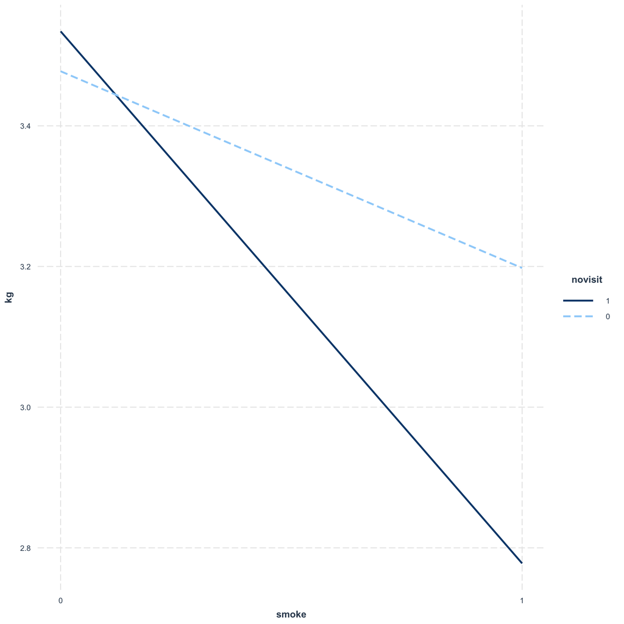

```r
# -----------------------------------------------
# simple slope
# -----------------------------------------------

interactions::probe_interaction(
    interaction_model,
    pred = novisit,
    modx = smoke
    )
```

```
## JOHNSON-NEYMAN INTERVAL
##
## When smoke is OUTSIDE the interval [-1.09, 0.50], the slope of novisit is p
## < .05.
##
## Note: The range of observed values of smoke is [0.00, 1.00]
##
## SIMPLE SLOPES ANALYSIS
##
## Slope of novisit when smoke = 0.00 (0):
##
##   Est.   S.E.   t val.      p
## ------ ------ -------- ------
##   0.06   0.12     0.47   0.64
##
## Slope of novisit when smoke = 1.00 (1):
##
##    Est.   S.E.   t val.      p
## ------- ------ -------- ------
##   -0.42   0.14    -3.02   0.00
```

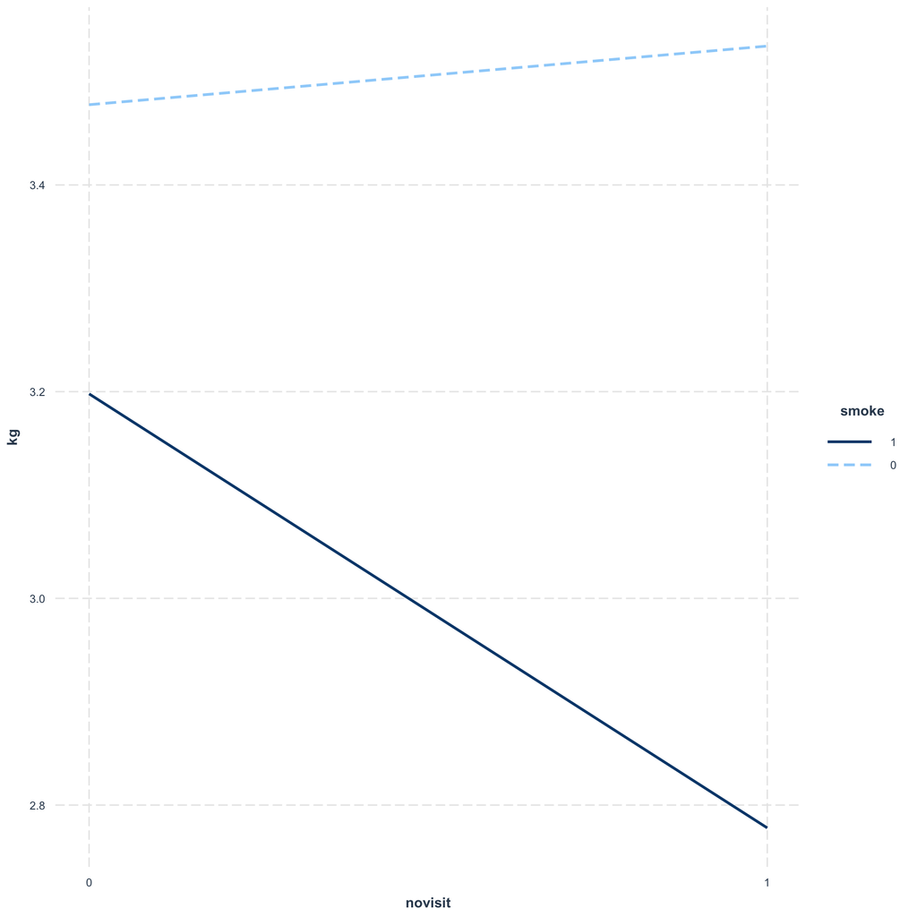

```
## JOHNSON-NEYMAN INTERVAL
##
## When novisit is OUTSIDE the interval [-2.48, -0.32], the slope of smoke is
## p < .05.
##
## Note: The range of observed values of novisit is [0.00, 1.00]
```

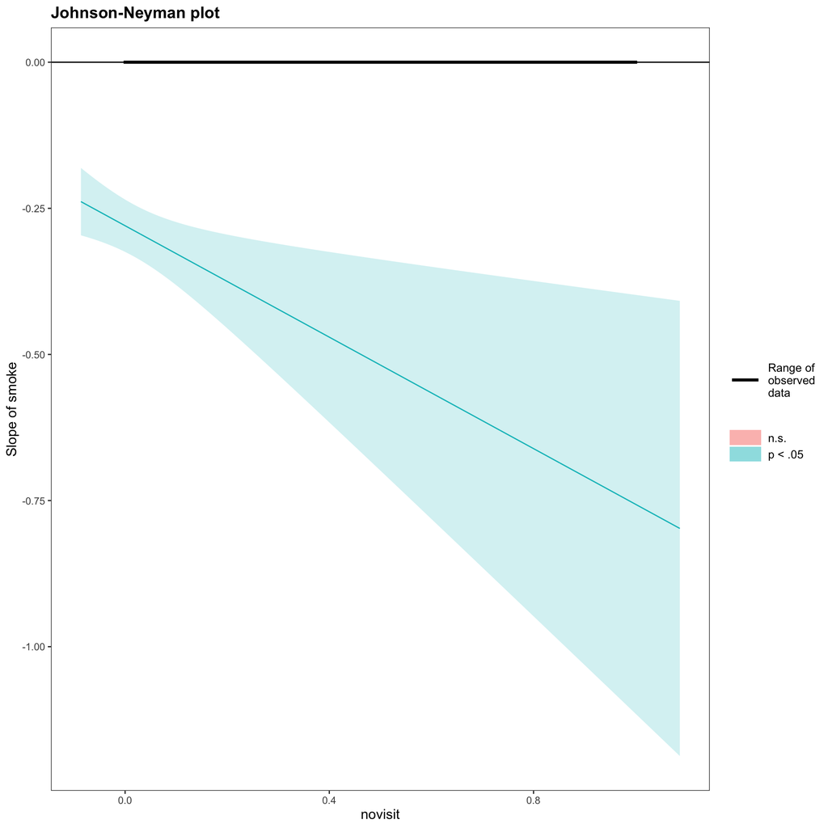

```r
# -----------------------------------------------
# johnson neyman plot
# -----------------------------------------------

interactions::johnson_neyman(
    interaction_model,
    pred = smoke,
    modx = novisit
    )
```

## Datos Perdidos

```r
#----------------------------------------------------------
# preparar datos
#----------------------------------------------------------

library(VIM)
```

[figure not shown]

```r
data_first %>%
dplyr::select(smoke, novisit, kg) %>%
VIM::aggr(.,
  combine=TRUE,
  cex.lab=.8,
  cex.axis=.6,
  col = c("white", "black"),
  ylabs="Pattern of omissions"
  )
```